# Quantification of sovereign risk: Using the information in equity market prices - ScienceDirect

## [Emerging Markets Review](https://www.sciencedirect.com/journal/emerging-markets-review)

[Volume 6, Issue 4](https://www.sciencedirect.com/journal/emerging-markets-review/vol/6/issue/4), December 2005, Pages 346-362

# Quantification of sovereign risk: Using the information in equity market prices

Graduate School of Business Sciences, The University of Tsukuba, Tokyo, 3-29-1 Otsuka, Bunkyo-ku, Tokyo 112-0012, Japan

Received 12 June 2005, Revised 2 September 2005, Accepted 9 September 2005, Available online 24 October 2005.

https://doi.org/10.1016/j.ememar.2005.09.001[Get rights and content](https://s100.copyright.com/AppDispatchServlet?publisherName=ELS&contentID=S1566014105000531&orderBeanReset=true)

Full text access

## Abstract

This paper proposes a new approach to quantify the sovereign risk. We use the information of the stock price index as a proxy for the equity value of the country, and introduce a size parameter, which is a conversion factor of the stock price index to the equity value of the country, and adopted the extended Black–Scholes–Merton option-pricing model for the calculation of the probability of default. Our model is applied on two countries, Argentina as the case of debt crisis and Thailand as currency crisis. We demonstrated a capability of our model as an early warning indicator for both crises.

## JEL classification

C53

F34

## Keywords

Sovereign risk

Probability of default

Stock price index

Option-pricing model

## 1. Introduction

It was commonly believed that the sovereign will never fall into default, however, the debt defaults in Latin countries happened in the early 1980s have reminded us an importance of the risk management even for sovereign countries. A number of models have been proposed for the evaluation of the sovereign risk. Most of these models are based on a statistical approach, for example, the multivariate discriminant analysis proposed firstly by Frank and Cline (1971) and the logistic regression analysis (e.g., Feder and Just, 1977). These models require various macroeconomic data as explanatory variables, however, it is inevitable that they cause a non-trifling time delay until the updated data become available. In addition, these data will be updated no more than once a year. These facts cause serious difficulties for the evaluation of the sovereign risks in timely manner.

Redeeming these shortcomings in the statistical approaches, the elaborate analysis by professional researchers seems to be helpful. In fact, the sovereign ratings issued by the rating agencies, such as Moody's or Standard and Poor's (S&P), are quite common as the reference of the sovereign risk. They conduct exclusive interviews to both politicians and officers in the country, and make macroeconomic forecast based on confidential information. Therefore, it is necessarily considered that the sovereign ratings should be a better reference than the simple quantitative statistical approach. As a number of papers pointed out,<sup>1</sup> however, the rating agencies indeed failed to predict the Asian crises that happened in 1997.

In the field of the corporate credit risk measurement, the Black–Scholes–Merton (BSM) option-pricing model<sup>2</sup> is fruitfully accepted, which is originally proposed by Black and Scholes (1973) and Merton (1974). Some of papers have applied the BSM option-pricing model to the measurement of sovereign risk. Gennotte et al. (1987) and Clark (1991) estimated the probability of default by employing an accumulated fixed capital formulation as the underlying asset in the option-pricing model. Kirmann and Maltritz (2003) showed the foreign exchange reserves and discounted that future net export incomes are the good proxy for the underlying asset or the ability to pay.

Chesney and Morisset (1992), Claessens and Pennacchi (1991) and Cumby and Evans (1997) estimated the probability of default based on a stochastic model. Meanwhile, Bhanot (1998), Izavorski (1998), Copeland and Jones (2001) and Merrick (2001) proposed a method to estimate the probability of default from the pricing model of sovereign bonds. Lehrbass (2000) proposed a pricing model of Eurobonds by use of equity indices.

In this paper, we propose a new model to quantify the sovereign risk. Our model is constructed based on the BSM option-pricing model, which enables us to evaluate sovereign risk in timely manner. We use a stock price index, as a proxy for the equity value of the country, and a sovereign bond-price.

We treat both debt default (debt crisis) and currency crisis. Although most of previous studies dealt with these two crises as separate issue, as Reinhart (2002) reported, there is a close relationship between defaults and currency crises, and indeed Reinhart (2002) showed the 58% samples of debt crises have fallen into defaults within twenty-four months after the currency crisis. We will examine the effectiveness of our model for predicting both debt and currency crises.

The remainder of this paper is organized as follows. Section 2 describes the usefulness of the information from the stock market in evaluating the credit risk, and its potential application to the sovereign risk. Section 3 describes the details of our model. Some results and reviews are summarized in Section 4. Our discussion and future extensions are in Section 5.

## 2. Proxy for the equity value of country

### 2.1. The concept of BSM model for risk analysis

Fig. 1 shows the payoff function to the equity holder and debts holders. Let *D*<sub>1</sub> and *D*<sub>2</sub> be the face values of senior and junior debt, respectively, and *D* be the total liability, i.e., *D* = *D*<sub>1</sub> + *D*<sub>2</sub>. *E* denotes the payoff to the equity holder, and *B*<sub>1</sub> and *B*<sub>2</sub> stands for the payoff to the senior and the junior debt holder, respectively. Then *B* ≡ *B*<sub>1</sub> + *B*<sub>2</sub> is the total payoff to the debt holders, which can be also recognized as the market value of the total debt. As shown in the Fig. 1, the market value of the debt, *B* is the put option on the value of the asset *V*, which is given by *B* = min(*V*, *D*). Taking the seniority of the debts into consideration, the values of the senior and junior debt will be *B*<sub>1</sub> = min(*V*, *D*<sub>1</sub>) and *B*<sub>2</sub> = min(*V* − *B*<sub>1</sub>, *D*<sub>2</sub>), respectively, since the junior debt *D*<sub>2</sub> is subordinated to the senior debt *D*<sub>1</sub>, their payoff or market value *B*<sub>2</sub> is the residue of the asset value after the payoff to the senior debt holder. The market value of the equity, *S* is subordinated to the senior and junior debts, thus, it will be the residue of the value of the asset after the payoff to the all debt holders, *E* = max(0, *V* − *B*) or equivalently *E* = max(0, *V* − *D*). <sup>3</sup> Therefore, the market value of asset *V* can be calculated from the total liability *D* and the market value of equity *E* which can be observed in the stock market.

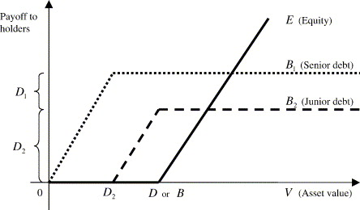

1. [Download: Download full-size image](https://ars.els-cdn.com/content/image/1-s2.0-S1566014105000531-gr1.jpg)

Fig. 1. Conceptual drawing of the payoff function to the equity holder and debts holders. *D*<sub>1</sub> and *D*<sub>2</sub> is the face values of senior and junior debt, respectively, and *D* is the total liability, *D* = *D*<sub>1</sub> + *D*<sub>2</sub>. *E* denotes the payoff to the equity holder, and *B*<sub>1</sub> and *B*<sub>2</sub> stand for the payoff to the senior and the junior debt holder, respectively. *B* ≡ *B*<sub>1</sub> + *B*<sub>2</sub> is the total payoff to the debt holders.

Under the BSM option-pricing model, the probability of default is given as the likelihood that the market value of the asset becomes less than the market value of its total liability at the maturity *T*, i.e., Pr(*V<sub>T</sub>* ≤ *D*). This will be discussed in detail in Section 3.1.

### 2.2. Market value of equity in country

In applying the BSM option-pricing model to sovereign risk, either the market value of the asset or the market value of equity in the country is necessary, unfortunately, both of them are not readily available. Instead, we can obtain the information from stock market, which may be useful as a proxy for the equity value of the country.<sup>4</sup> The equity market is not established in all countries, however, it covers over 70 countries including all financially major countries. We examine the relationship between the stock price index and the equity value of the country in following.

### 2.3. Stock price index and the equity value of country

There exists some methods to analyze the equity values of countries. United Nations proposed Systems of National Accounts (abbreviated to SNA), which is constituted of 5 major accounts such as National Income Accounts, Balance of Payments and National Balance Sheets. The National Balance sheets contains the information of equity value of the country, however, it is provided by a limited number of countries.

Clark (1991) proposed the concept of macroeconomic balance sheet. The macroeconomic balance sheet is prepared by the time series data of National Income Accounts and Balance of Payments, which are available for most of countries. The macroeconomics balance sheet is constructed from three parts, the asset, the liability and the equity, as shown in Table 1. The equity value of the country can be calculated as “assets” minus “liabilities.”

Table 1. Macroeconomic balance sheet at time *T*

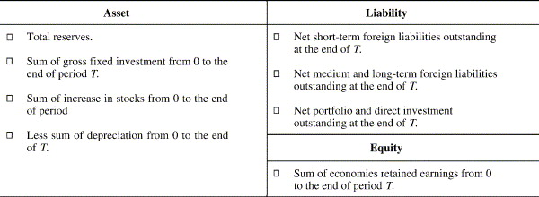

We calculated the macroeconomic balance sheets for Argentina and Thailand, where the depreciation rate for the fixed asset is assumed to be 10% each year, and the accumulations are made retroactively from 1970 to 1999, all data are denominated in US dollars. The amount of liability is collected from Global Development Finance (GDF) issued by World Bank. Fig. 2 shows the transitions of the equity values of the country obtained from above calculation and the stock price index for Thailand and Argentina. The stock price indices are obtained from Morgan Stanley Capital International's (MSCI) capital indices as an average through the year. Table 2 shows the Pearson correlation coefficients between stock price index and the equity value of the country, where we demonstrate the same calculation for 10 countries in total.

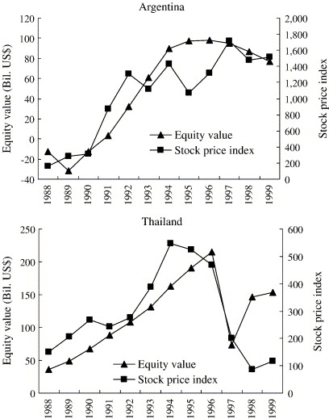

1. [Download: Download full-size image](https://ars.els-cdn.com/content/image/1-s2.0-S1566014105000531-gr2.jpg)

Fig. 2. The transitions of stock price index and equity value for Argentina and Thailand. Stock price index is obtained from MSCI's equity indices as an average through the year. Equity values are calculated based on the concept of macroeconomic balance sheet proposed by Clark (1991).

Table 2. Pearson correlation coefficients between the stock price index and the equity value of the country

| Country | Correlations 1988–1999 |
| --- | --- |
| Thailand | 64.4% |
| Indonesia | 61.9% |
| Malaysia | 65.3% |
| Philippines | 80.2% |
| Argentina | 87.0% |
| Brazil | 87.5% |
| Mexico | 77.3% |
| Chile | 83.2% |
| Pakistan | 72.7% |
|  | (1993–1999) |
| Peru | 72.3% |
|  | (1993–1999) |

The stock price index is obtained from MSCI's equity index. The index is available from the end of 1987, except Pakistan and Peru, which is available after 1993.

They show that the stock price index is tightly related to the equity value of the country. In consideration of this concordance, this will be good evidence that the stock price index will be a good proxy of the equity value of the country.

### 2.4. Transformation of stock price index into the equity value of the country

Our model employs the stock price index of the country. The stock price index is a relative value measuring from a specific origin date, and depends on the market. In the case of MSCI's stock index, for most of countries, 31st of December, 1987, is the origin of the index as 100. Given a country, in order to transform the stock price index into the equity value *E*<sub>*t*</sub> of the country at time *t*, which is an absolute value, we employ the following equality:(1)$Et=αSt$where *S*<sub>*t*</sub> is the stock price index, and *α* stands for a constant parameter for the country. *α* can be understood as a specific scaling parameter between *E*<sub>*t*</sub> and *S*<sub>*t*</sub>. Each country has its own scaling parameter *α* and we call *α* as “size parameter”, and assume that *α* is unique to the country and constant in time.

## 3. Evaluation of sovereign risk

### 3.1. Option-pricing model

In the BSM option-pricing model, the asset value *V*<sub>*t*</sub> of a country at time *t* is assumed to follow the stochastic differential process:$dVt/Vt=μV+σVdWt$where *μ*<sub>*v*</sub> is a growth rate of the asset, *σ*<sub>*v*</sub> is a volatility of the asset, and *W*<sub>*t*</sub> is a Winner process. In applying Ito's formula, the natural log of asset value at time *T* is distributed normally as follows,(2)$lnVT∼Norm[lnVt+(μV−σ2V2)τ,σV2τ],$where Norm[*X*, *Y*] is the normal distribution function with mean *X* and variance *Y*, and *τ* ≡ *T* − *t* is the risk horizon. We assume that the country will fall into default if the asset value *V*<sub>*T*</sub> becomes less than the value of the foreign liability *D*<sub>*T*</sub> at the maturity date *T*. The expected probability of default *P*<sub>*t*(*T*)</sub> will be given in the following form:(3)$Pt(T)=Pr(VT≤DT|Vt)=Pr(lnVT≤lnDT|lnVt)=N(lnDT−[lnVt+(μV−σV2/2)τ]σVτ)=N(−d2)$where$d2≡ln(Vt/DT)+(μV−σV22)τσVτ$and *N*(·) is the cumulative normal distribution function. The market value of the equity *E*<sub>*t*</sub> at time *t* becomes:(4)$Et=VtN(d1)−DTe−μVτN(d2).$where $d1≡d2+σVτ$.

Eqs. (3), (4) contain three unknown parameters *μ*<sub>*V*</sub>, *σ*<sub>*V*</sub> and *V*<sub>*t*</sub>. We employ an iterative method proposed by Chesney and Morisset (1992) for estimating parameters. In our model, we firstly set a size parameter *α* some value, and solve the Eqs. (2), (3), (4). Then, the size parameter will be calibrated properly by use of the bond-prices.

### 3.2. Theoretical bond-price

For time *t*, let *p¯*<sub>*t*(*s*)</sub> be the probability that the bond first falls into default at time *t* + *s* under the condition that there is no default occurred prior to *t* + *s*. We hereby assume that the conditional probability of default *p¯*<sub>*t*(*s*)</sub> has a flat term structure, *p¯*<sub>*t*(*s*)</sub> = *p*<sub>*t*</sub> for all *s*.<sup>5</sup> The probability of default from *t* to *t* + *s* would be *P*<sub>*t*(*s*)</sub> = 1 − (1 − *p<sub>t</sub>*)<sup>*s*</sup>. The present value of the fixed-rate coupon bond at time *t* with NC periods to maturity will be given by the following formula:(5)$Bt=∑i=1NC{(1−Pt(i))dt(i)cF}+(1−Pt(NC))dt(NC)F+∑i=1NC(βtptdt(i)F)$where *d*<sub>*t*(*k*)</sub> is the discount factor and given in *d*<sub>*t*(*k*)</sub> =1 / (1 + *r*<sub>*t*(*k*)</sub>)<sup>*k*</sup>, *r*<sub>*t*(*k*)</sub> is the yield rate of a U.S. Treasury zero-coupon bond maturing at *t* + *k*,<sup>6</sup> *c* is a coupon rate, *F* is the face value of the bond, *β*<sub>*t*</sub> is the recovery rate. We assume that the recovery rate *β*<sub>*t*</sub> is constant through to the maturity but varying on time *t*, and the recovery value *β*<sub>*t*</sub>*F* will be paid immediately upon its default. The first term of the RHS of Eq. (5) means the cash flow from coupon payments, the second term is the payment of principle, and the last term is the recovery amount when it defaults.

### 3.3. The liabilities and their maturities

The data of foreign liabilities are collected from GDF. However, we need to pay attention to these data when applying to Eq. (3), because the foreign liability of the country is a mixture of various face values and maturities. In accordance with Clark and Marois (1996), we consider that the sum of all the contractual debt service payments coming due in the future including interest and principal is a good estimation of *D*<sub>*T*</sub>, and the time to maturity, *τ* is estimated as the Macaulay duration<sup>7</sup> of such payments.

### 3.4. Optimization of size parameter

In order to determine the size parameter *α* and recovery rate *β*<sub>*t*</sub>, we employed the following algorithm.

- Step 1

  Set a size parameter *α˜* appropriately, and calculate the probability of default *P*<sub>*t*(*T*)</sub> by the Eqs. (3), (4).
- Step 2

  The theoretical bond-price *B˜*<sub>*t*</sub> at time *t* is obtained from Eq. (5) as the function of *α˜* and an assumed recovery rate *β˜*<sub>*t*</sub>, i.e., *B˜*<sub>*t*</sub> =*f*(*α˜*, *β˜*<sub>*t*</sub>). The optimal recovery rate *β*<sub>*t*</sub>* will be given as the point of minimization between the estimated theoretical bond-price and the observed bond-price in the market *B*<sub>*t*</sub><sup>*M*</sup>. The grid search method is used to obtain the optimal recovery rate.<sup>8</sup>(6)$βt*=argminβ˜t{(BtM−f(α˜,β˜t))2|α˜}.$
- Step 3

  The parameter calibration process will be repeated for the certain periods (0 ≤ *t* ≤ *T*<sub>*c*</sub>), and we hereinafter call it the calibration periods. The optimal size parameter *α** will be given as the point of minimization for the sum of the residual values between the theoretical bond-prices *B˜*<sub>*t*</sub>* = *f*(*α˜*, *β*<sub>*t*</sub>*) and the observed bond-prices in the market *B*<sub>*t*</sub><sup>*M*</sup> under the optimal recovery rate *β*<sub>*t*</sub>*,(7)$α*=argminα˜{∑t=0Tc(BtM−f(α˜,βt*))2|βt*}.$

Since *α** cannot be determined analytically, the grid search method is used to obtain the optimal value. The optimal value of the size parameter *α** is the country specific and constant in time.

## 4. Results

### 4.1. Selected countries

We apply the model on two countries, Argentina and Thailand. Argentina fell into default on their foreign debt in November 2001, and Thailand faced the sharp devaluation of their currency in July 1997. Both cases left the serious impacts on world equity and currency markets. These will be good cases to test whether our model has a capability as an early warning indicator for both debt and currency crisis.

#### 4.1.1. Stock price indices

Several stock price indices exist for these countries. In general, the stock exchange market in each country provides their own index, and in addition, some security companies issue their unique indices based on their own methodology. For example in the market of United States, there are S&P 500, DJIA, NASDAQ composite and more indices. Each index has different process to select companies composing the indices. In the emerging markets, there are two major indices, Morgan Stanley Capital International (MSCI) and S&P (formerly International Finance Corporation). We use MSCI's equity index denominated in US dollar. The indices are announced on daily basis, and cover 23 developed and 27 emerging countries. MSCI's equity index captures 60% of the total market capitalization of the country.

#### 4.1.2. Bond-prices

Table 3 shows the details of sovereign bonds used for the calibration. All data are collected from DataStream terminal. Each country usually issues a number of bonds with different coupons and maturities. The reasons we select these bonds are as follows; first, these bonds are ordinal fixed coupon bonds. Floating rate bond or collateralized bond like Brady bond is not suitable for the calculation of Eq. (5).<sup>9</sup> Second, the currency is denominated in US dollar. Finally, these bond-prices are available for longer periods than other sovereign bonds that we can obtain.

Table 3. Details of the sovereign bonds used for the parameter calibrations

[output not shown]

These data are collected from DataStream terminal.

### 4.2. Default probabilities

Table 4 shows the optimal size parameters *α** calculated from Eq. (7). The search step of the size parameter is a crucial for the accuracy of the results, but it is also proportional to the calculation burden. We have determined an appropriate search step country by country, i.e., 5 for Thailand and 1 for Argentina.

Table 4. Size parameters and search steps

| Empty Cell | Optimal size parameter *α** | Search step for size parameter *α* | Search step for recovery rate *β* |
| --- | --- | --- | --- |
| Thailand | 80 | 5 | 5% |
| Argentina | 7 | 1 | 5% |

Fig. 3 shows the probability of default calculated from Eq. (3) based on the optimal size parameter *α** for the period from Jan. 94 to Dec. 2001, and the stock price index is also shown as a reference. The perpendicular bold dashed line shows the line of the debt default for Argentina and the currency crisis for Thailand.

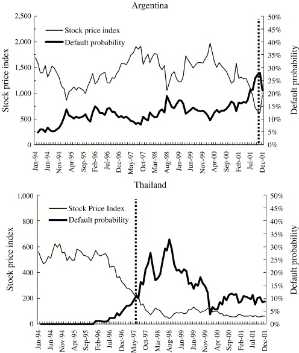

1. [Download: Download full-size image](https://ars.els-cdn.com/content/image/1-s2.0-S1566014105000531-gr3.jpg)

Fig. 3. Default probability and stock price index. The perpendicular bold dashed line shows the line of debt default for Argentina and the currency crisis for Thailand. The default probabilities are calculated from Eq. (3).

Argentina has defaulted on their foreign debt in November 2001. The probability of default keeps high around 10% to 15% since the early 1995, and it sharply climbs out from July 2001, which was 4 months prior to the debt default. At the debt default in November 2001, the probability of default pointed to the peak of 28%. Meanwhile, for Thailand, the default probabilities start to increase from early 1996. It was almost one year prior to the crisis in July 1997, and it sharply climbs out after the crisis, and became more than 30% at the peak in 1998. After the end of 1999, when the currency crisis seemed to be settled, the probability of default becomes stable around 5% to 10%.

### 4.3. Recovery rate

Fig. 4 shows the recovery rate optimally estimated from Eq. (6). This may be called as the implied recovery rate.<sup>10</sup> The fundamental meaning of the recovery rate in Eq. (5) is the fraction of the expected recovery amount and the face value of the bond when it falls into default. In our model, it also works as an adjustment factor for the price difference between estimated theoretical bond-price, *B˜*<sub>*t*</sub> and observed bond-price, *B*<sub>*t*</sub><sup>*M*</sup>. In other words, the recovery rate will be endogenously determined in order to equalize the price of *B˜*<sub>*t*</sub> with *B*<sub>*t*</sub><sup>*M*</sup> under the given default probability.

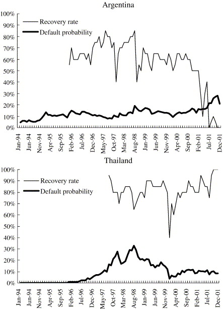

1. [Download: Download full-size image](https://ars.els-cdn.com/content/image/1-s2.0-S1566014105000531-gr4.jpg)

Fig. 4. Default probability and recovery rate. The recovery rates are optimally estimated from Eq. (6). Every country seems to have a mean level of the recovery rate, around 60% to 70% for Argentina, and around 80% to 90% for Thailand.

Fig. 5 compares the observed bond-price in the market with the theoretical bond-price in adopting the optimally estimated recovery rate, *β*<sub>*t*</sub>*. They indicate good agreements throughout the period. These results show that our bond-pricing model works well throughout the period.

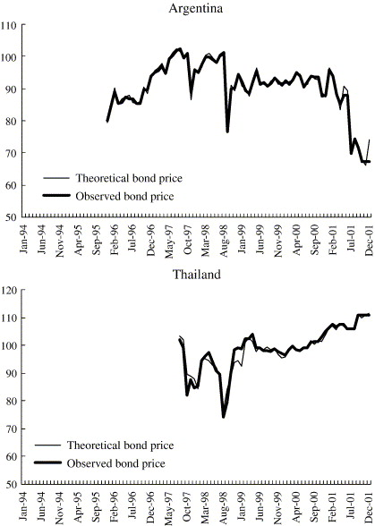

1. [Download: Download full-size image](https://ars.els-cdn.com/content/image/1-s2.0-S1566014105000531-gr5.jpg)

Fig. 5. Comparison between the observed bond-price in the market and the theoretical bond-price. The theoretical bond-price is calculated under the optimally estimated recovery rate.

From scrutiny of Fig. 4, we can perceive that every country has a mean level of the recovery rate, for instance, the mean level of Argentina is around 60% to 70% , and Thailand is around 80% to 90%. As an examination, we fixed the recovery rates at 85% for Thailand and 65% for Argentina, the results are shown in Fig. 6. We will notice that the difference between theoretical and observed bond-prices shows an acceptable agreement throughout the period, however, the differences occasionally become widen, especially during the crisis, Asian currency crisis, Argentina debt crisis and interestingly Russian debt crisis in August 1998 as well.<sup>11</sup> These price differences vanished in a relatively short period. This means the bond-price observed in the market is very sensitive against the credit events happened even in foreign countries. It responds to the credit events, and overshoots more than the price theoretically estimated from the probability of default.<sup>12</sup> However, the observed price reverts quickly to the level of theoretical price once the credit event has calmed. One of the reasons for this overshoot may be the liquidity problem of the bond during the crisis. In addition, we can point out another reason, pricing error of the market, which means that the investors may recognize the probability of default worse than that of theoretically expected. By analyzing this error, there may be a good opportunity to take an arbitrage trading. Another empirical study will be required for this area.

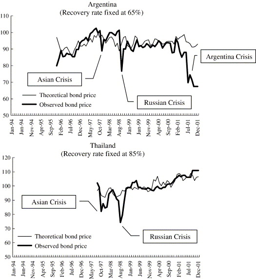

1. [Download: Download full-size image](https://ars.els-cdn.com/content/image/1-s2.0-S1566014105000531-gr6.jpg)

Fig. 6. Comparison between the observed bond-price in the market and the theoretical bond-price. The recovery rate is fixed at 65% for Argentina and 85% for Thailand. The large price gaps are observed when the crises have happened even in other countries.

### 4.4. Comparison with sovereign ratings

In Fig. 7, we compare the probability of default obtained by our model with S&P's sovereign ratings. In Argentina, our model keeps higher probability of default throughout the periods, but S&P's sovereign rating shows BB− and even upgraded to BB in early 1997. Then, S&P's sovereign rating started to downgrade from the end of 2000. On the other hand, the probability of default in our model started to climb out at the same time, which is almost one year prior to the debt default. Meanwhile, in Thailand, the S&P's sovereign rating is very high until the currency crisis, and then substantially downgraded after the crisis. On the other hand, our model shows that the probability of default started to climb out sharply from 1996 which is more than one year prior to the crisis. These evidences clearly show that our model has a better performance than the sovereign ratings as an early warning indicator.

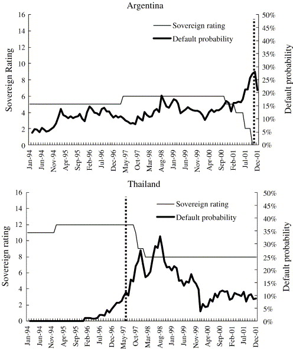

1. [Download: Download full-size image](https://ars.els-cdn.com/content/image/1-s2.0-S1566014105000531-gr7.jpg)

Fig. 7. Comparison between the default probability and sovereign rating. The sovereign ratings are based on S and P. The numbers are corresponded as follows: AAA = 17, AA + = 16, AA = 15, AA− = 14, …, BB = 6, BB− = 5, B + = 4, B = 3, B− = 2, CCC + = 1, CCC and under = 0. The perpendicular bold dashed line shows the line of the debt default for Argentina and the currency crisis for Thailand.

### 4.5. Comparison with bond spreads

Fig. 8 shows the comparison of the probability of default obtained by our model with bond spread. The bond spread is calculated under following simplified formula:(8)$ln(BtNR/BtM)/τ$where *B*<sub>*t*</sub><sup>*M*</sup> is the observed bond-price, and *B*<sub>*t*</sub><sup>NR</sup> is the theoretical bond-price with no default risk under the assumption that the both bonds have the same cash flows and the time to maturity *τ*.

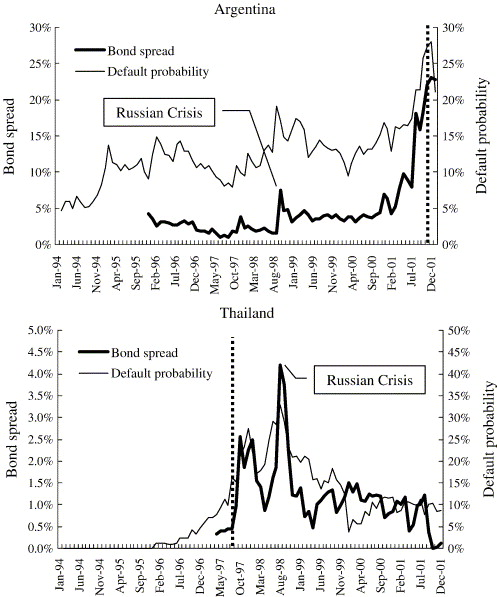

1. [Download: Download full-size image](https://ars.els-cdn.com/content/image/1-s2.0-S1566014105000531-gr8.jpg)

Fig. 8. Comparison between the default probability and bond spread. The bond spreads are calculated from Eq. (8).

In both cases, the bond spreads show spikes to the credit events in Russian. In the case of Argentina, the bond spreads expand from 1.56% to 7.45% in one month, and 1.86% to 4.20% in Thailand. This is a peculiarity of bond spread and it is not a favorable nature from the viewpoint of risk evaluation. The desired nature is that the risk index starts to increase well in advance of the events, and does not fluctuate too much during the calm period. In this sense, the results from our model have better nature as the risk index.

## 5. Discussion and future extensions

### 5.1. Parameter estimation

The bond-price issued by sovereign is used in our model. Each sovereign issues a number of bonds. If the parameters are calibrated only from a specific bond-price, the results may be biased. In order to avoid these unfavorable results, it is recommended to use a set of bonds. In this case, the Eq. (7) could be modified to minimize the sum of price differences of a set of bonds, *i*:(9)$α*=argminα˜∑i{∑t=0Tc(BtM,i−B˜t*i)2|βt*i}$where *B˜*<sub>*t*</sub>*<sup>*i*</sup> is the function of *α˜* and *β*<sub>*t*</sub>*<sup>*i*</sup>. *β*<sub>*t*</sub>* may be different bond by bond since each bond has his own features and attributes.

Furthermore, as we have seen in Section 4.5, the bond-price might be spiked or be overshot in the case that credit events have happened. This would cause unfavorable bias on the results if we make calibration only in short period. Therefore, it will be suitable to take the calibration period as long as possible.

### 5.2. Modeling default process

In Eq. (3), we have assumed that the default will occur only at the maturity date if the asset value is less than the value of foreign liability at the date. In consideration of practical situation, the default may occur even before the maturity date. In option pricing model, the former model is called as European type which is expressed as $Pt(T)=Pr(VT≤DT|VT)$, and the later model is called as the first passage time model or knockout option model which is expressed as(10)$Pt(T)=Pr(mint≤u≤TVu≤DT|Vt).$

Ando and Marumo (2001) discussed that the probability of default by knockout option model generally indicates higher probability than that of European type model. From this result, we can expect that the optimal size parameter *α** will take a bigger number in the case that the knockout option model is employed instead of European type model. Since the bigger size parameter will decrease the probability of default, this will offset the increment of the probability of default by use of the knockout option model. From above discussion, it is worthwhile to note that the size parameter may vary depending on the adopted model.

### 5.3. Modeling of the willingness-to-pay

The sovereign may suspend their contractual obligations even if they are solvent, because the lenders have only limited power to punish sovereign borrowers and the international legal framework is not well developed for the recovery rules and processes from the defaulted borrowers. This will be a major factor to make distinct the sovereign borrower from corporate borrower. This was firstly discussed by Eaton and Gersovitz (1981), and is well known as the willingness-to-pay problem.

If there is willingness-to-pay problem, the payoff function to the sovereign bondholder will shift to the right, which is similar to the junior debt against the senior debt as shown in Fig. 1. Therefore, if we interpret the amount of *D*<sub>1</sub> as the level of unwillingness, we can discuss the willingness-to-pay problem under the same framework.

## References

1. Ando and Marumo, 2001

   A. Ando, K. Marumo

   Estimation of default probability by use of knock-out option approach — comparison with European option approach (in Japanese)

   IMES Discussion Paper No.2001-J-4, Bank of Japan (2001)

   Google Scholar
2. Bhanot, 1998

   K. Bhanot

   Recovery and implied default in Brady bonds

   The Journal of Fixed Income, 8 (1998), pp. 47-51

   [Crossref](https://doi.org/10.3905/jfi.1998.408231)[Google Scholar](https://scholar.google.com/scholar_lookup?title=Recovery%20and%20implied%20default%20in%20Brady%20bonds&publication_year=1998&author=K.%20Bhanot)
3. Black and Scholes, 1973

   F. Black, M. Scholes

   The pricing options and corporate liabilities

   Journal of Political Economy, 3 (1973), pp. 637-654

   [Google Scholar](https://scholar.google.com/scholar_lookup?title=The%20pricing%20options%20and%20corporate%20liabilities&publication_year=1973&author=F.%20Black&author=M.%20Scholes)
4. Chesney and Morisset, 1992

   M. Chesney, J. Morisset

   Measuring the risk of default in six highly indebted countries

   Working Papers WPS916, World Bank (1992)

   [Google Scholar](https://scholar.google.com/scholar_lookup?title=Measuring%20the%20risk%20of%20default%20in%20six%20highly%20indebted%20countries&publication_year=1992&author=M.%20Chesney&author=J.%20Morisset)
5. Claessens and Pennacchi, 1991

   S. Claessens, G. Pennacchi

   Estimating the likelihood of Mexican default from the market prices of Brady bonds

   Journal of Financial and Quantitative Analysis, 31 (1991), pp. 109-126

   Google Scholar
6. Clark, 1991

   E. Clark

   Cross-Border Investment Risk

   Euromoney Books (1991)

   [Google Scholar](https://scholar.google.com/scholar_lookup?title=Cross-Border%20Investment%20Risk&publication_year=1991&author=E.%20Clark)
7. Clark and Marois, 1996

   E. Clark, B. Marois

   Managing Risk in International Business, Chapter 6

   International Thomson Business Press (1996)

   [Google Scholar](https://scholar.google.com/scholar_lookup?title=Managing%20Risk%20in%20International%20Business%2C%20Chapter%206&publication_year=1996&author=E.%20Clark&author=B.%20Marois)
8. Copeland and Jones, 2001

   L. Copeland, S.-A. Jones

   Default probabilities of European sovereign debt: market-based estimates

   Applied Economics Letters, 8 (2001), pp. 321-324

   [View in Scopus](https://www.scopus.com/inward/record.url?eid=2-s2.0-0035042189&partnerID=10&rel=R3.0.0)[Google Scholar](https://scholar.google.com/scholar_lookup?title=Default%20probabilities%20of%20European%20sovereign%20debt%3A%20market-based%20estimates&publication_year=2001&author=L.%20Copeland&author=S.-A.%20Jones)
9. Cumby and Evans, 1997

   R. Cumby, M. Evans

   The Term Structure of Credit Risk: Estimate and Specification Tests, Working Paper

   Department of Economics, Georgetown University (1997)

   Google Scholar
10. Cumby and Pastine, 2001

    R. Cumby, T. Pastine

    Emerging market debt: measuring credit quality and examining relative pricing

    Journal of International Money and Finance, 20 (2001), pp. 591-609

    [View PDF](https://www.sciencedirect.com/science/article/pii/S0261560601000183/pdfft?md5=412b28b4abee2e21ae503c363f2525c8&pid=1-s2.0-S0261560601000183-main.pdf)[View article](https://www.sciencedirect.com/science/article/pii/S0261560601000183)[View in Scopus](https://www.scopus.com/inward/record.url?eid=2-s2.0-0042326382&partnerID=10&rel=R3.0.0)[Google Scholar](https://scholar.google.com/scholar_lookup?title=Emerging%20market%20debt%3A%20measuring%20credit%20quality%20and%20examining%20relative%20pricing&publication_year=2001&author=R.%20Cumby&author=T.%20Pastine)
11. Eaton and Gersovitz, 1981

    J. Eaton, M. Gersovitz

    Debt with potential repudiation: theory and estimation

    Review of Economic Studies, 48 (1981), pp. 289-309

    [Crossref](https://doi.org/10.2307/2296886)[View in Scopus](https://www.scopus.com/inward/record.url?eid=2-s2.0-84959777265&partnerID=10&rel=R3.0.0)[Google Scholar](https://scholar.google.com/scholar_lookup?title=Debt%20with%20potential%20repudiation%3A%20theory%20and%20estimation&publication_year=1981&author=J.%20Eaton&author=M.%20Gersovitz)
12. Feder and Just, 1977

    G. Feder, R. Just

    A study of debt servicing capacity applying logit analysis

    Journal of Development Economics, 4 (1977), pp. 25-38

    [View PDF](https://www.sciencedirect.com/science/article/pii/0304387877900049/pdf?md5=a55baeb023093ae7d863c10be9abe635&pid=1-s2.0-0304387877900049-main.pdf)[View article](https://www.sciencedirect.com/science/article/pii/0304387877900049)[View in Scopus](https://www.scopus.com/inward/record.url?eid=2-s2.0-0002909256&partnerID=10&rel=R3.0.0)[Google Scholar](https://scholar.google.com/scholar_lookup?title=A%20study%20of%20debt%20servicing%20capacity%20applying%20logit%20analysis&publication_year=1977&author=G.%20Feder&author=R.%20Just)
13. Frank and Cline, 1971

    C. Frank, W. Cline

    Measurement of debt servicing capacity: an application of discriminant analysis

    Journal of International Economics, 1 (1971), pp. 327-344

    [View PDF](https://www.sciencedirect.com/science/article/pii/0022199671900043/pdfft?md5=806788f72f0ffa71e04e4f3a7f911528&pid=1-s2.0-0022199671900043-main.pdf)[View article](https://www.sciencedirect.com/science/article/pii/0022199671900043)[View in Scopus](https://www.scopus.com/inward/record.url?eid=2-s2.0-0001573206&partnerID=10&rel=R3.0.0)[Google Scholar](https://scholar.google.com/scholar_lookup?title=Measurement%20of%20debt%20servicing%20capacity%3A%20an%20application%20of%20discriminant%20analysis&publication_year=1971&author=C.%20Frank&author=W.%20Cline)
14. Gennotte et al., 1987

    G. Gennotte, H. Kharas, S. Sadeq

    A valuation model for developing-country debt with endogenous rescheduling

    World Bank Economic Review, 1 (1987), pp. 237-271

    [Crossref](https://doi.org/10.1093/wber/1.2.237)[View in Scopus](https://www.scopus.com/inward/record.url?eid=2-s2.0-0023067199&partnerID=10&rel=R3.0.0)Google Scholar
15. Goldstein et al., 2000

    M. Goldstein, G. Kaminsky, C. Reinhart

    Assessing Financial Vulnerability

    Institute for International Economics (2000)

    [Google Scholar](https://scholar.google.com/scholar_lookup?title=Assessing%20Financial%20Vulnerability&publication_year=2000&author=M.%20Goldstein&author=G.%20Kaminsky&author=C.%20Reinhart)
16. Kirmann and Maltritz, 2003

    A. Kirmann, D. Maltritz

    Sovereign risk in a structural approach — evaluating sovereign ability-to-pay and probability of default

    Dresden Discussion Paper Series in Economics, No.7/03 (2003)

    Google Scholar
17. Kraussl, 2000

    R. Kraussl

    Sovereign Ratings and their Impact on Recent Financial Crises, Working Paper, Center of Financial Studies, Frankfurt/Main

    (2000)

    Google Scholar
18. Izavorski, 1998

    I. Izavorski

    Brady bonds and default probabilities

    IMF Working Paper, WP/98/16 (1998)

    [Google Scholar](https://scholar.google.com/scholar_lookup?title=Brady%20bonds%20and%20default%20probabilities&publication_year=1998&author=I.%20Izavorski)
19. Lehrbass, 2000

    F. Lehrbass

    A simple approach to country risk

    J. Franke, W. Hardle, G. Stahl (Eds.), Measuring Risk in Complex Stochastic Systems, Lecture Notes in Statistics, vol. 147, Springer (2000), pp. 33-67

    [Crossref](https://doi.org/10.1007/978-1-4612-1214-0_3)[Google Scholar](https://scholar.google.com/scholar_lookup?title=A%20simple%20approach%20to%20country%20risk&publication_year=2000&author=F.%20Lehrbass)
20. Merrick, 2001

    J. Merrick Jr.

    Crisis dynamics of implied default recovery ratios: evidence from Russia and Argentina

    Journal of Banking and Finance, 25 (2001), pp. 1921-1939

    [View in Scopus](https://www.scopus.com/inward/record.url?eid=2-s2.0-0011706663&partnerID=10&rel=R3.0.0)[Google Scholar](https://scholar.google.com/scholar_lookup?title=Crisis%20dynamics%20of%20implied%20default%20recovery%20ratios%3A%20evidence%20from%20Russia%20and%20Argentina&publication_year=2001&author=J.%20Merrick%20Jr.)
21. Merton, 1974

    R. Merton

    On the pricing of corporate debt: the risk structure of interest rates

    Journal of Finance, 29 (1974), pp. 449-470

    [Google Scholar](https://scholar.google.com/scholar_lookup?title=On%20the%20pricing%20of%20corporate%20debt%3A%20the%20risk%20structure%20of%20interest%20rates&publication_year=1974&author=R.%20Merton)
22. Pettis, 2001

    M. Pettis

    The Volatility Machine, Oxford University Press (2001), pp. 214-215

    [Google Scholar](https://scholar.google.com/scholar_lookup?title=The%20Volatility%20Machine&publication_year=2001&author=M.%20Pettis)
23. Reinhart, 2002

    C. Reinhart

    Default, Currency Crises and Sovereign Credit Ratings, NBER Working Paper, No.8738

    (2002)

    [Google Scholar](https://scholar.google.com/scholar_lookup?title=Default%2C%20Currency%20Crises%20and%20Sovereign%20Credit%20Ratings%2C%20NBER%20Working%20Paper%2C%20No.8738&publication_year=2002&author=C.%20Reinhart)

## Cited by (24)

### [Linkage dynamics of sovereign credit risk and financial markets: A bibliometric analysis](https://www.sciencedirect.com/science/article/pii/S0275531921001872)

- 2022, Research in International Business and Finance

  Citation Excerpt :

### [Modeling systemic risk of crude oil imports: Case of China's global oil supply chain](https://www.sciencedirect.com/science/article/pii/S036054421730018X)

- 2017, Energy

### [Analysing interconnectivity among economies](https://www.sciencedirect.com/science/article/pii/S156601411100046X)

- 2011, Emerging Markets Review

  Citation Excerpt :

### [Corporate Financial Distress, Restructuring, and Bankruptcy: Analyze Leveraged Finance, Distressed Debt, and Bankruptcy, Fourth Edition](https://doi.org/10.1002/9781119541929)

- 2019, Corporate Financial Distress Restructuring and Bankruptcy Analyze Leveraged Finance Distressed Debt and Bankruptcy Fourth Edition

### [A ratings-based approach to measuring sovereign risk](https://doi.org/10.1002/ijfe.357)

- 2008, International Journal of Finance and Economics

### [The dynamic pricing of sovereign risk in emerging markets: Fundamentals and risk aversion](https://doi.org/10.3905/jfi.2008.705542)

- 2008, Journal of Fixed Income

**<sup>1</sup>**

For example, see Goldstein et al. (2000), Kraussl (2000).

**<sup>2</sup>**

This approach is sometimes referred to as “structural approach.”

**<sup>3</sup>**

This payoff function shows the equity value is a call option on the value of the asset with a strike price equal to the total liability.

**<sup>4</sup>**

Pettis (2001) discussed the country's “underlying asset value,” and stated, “one possibility is that some proxy for the country's equity markets – such as a broad-based equity index – could also serve as a proxy for the underlying assets.”

**<sup>5</sup>**

Cumby and Evans (1997) and Merrick (2001) reported that the probability of default has a term structure. However, the form of the structure cannot be described explicitly and heavily indebted to the data for parametric estimations, which will cause difficulty to obtain relevant results. For simplicity purpose, we assumed the flat term structure in our model.

**<sup>6</sup>**

The yield rate of a U.S. Treasury zero-coupon bond is obtained by linear interpolation of spot rates with three and six months and one, two, five, ten and thirty years.

**<sup>7</sup>**

Macaulay duration is calculated as the time-weighted discount cash flow.

**<sup>8</sup>**

Considering heavy computational burden, we searched the recovery rate from 0 to 1 by every 5% step.

**<sup>9</sup>**

Cumby and Pastine (2001) investigated the pricing of Brady bonds.

**<sup>10</sup>**

We cannot observe the recovery rate directly in the market data, but it is “implied” and must be estimated from the data.

**<sup>11</sup>**

Russia declared the payment rescheduling for their domestic debt, GKO(Gosudarstvennye Kratkosrochnye Obyazatel'stva).

**<sup>12</sup>**

We may say the situation as “deeply discounted.”

Copyright © 2005 Elsevier B.V. All rights reserved.

[Assessing Risk in Emerging Markets](https://www.sciencedirect.com/science/journal/15660141/6/4)

Edited by

Javier Estrada, Campbell Harvey

### [An emerging market credit scoring system for corporate bonds](https://www.sciencedirect.com/science/article/pii/S1566014105000518)

- December 2005

  Edward I. Altman

  [View PDF](https://www.sciencedirect.com/science/article/pii/S1566014105000518/pdfft?md5=1bcfdc547e65ff4481e151d0dfa51cf0&pid=1-s2.0-S1566014105000518-main.pdf)

### [Modelling country spillover effects in country risk ratings](https://www.sciencedirect.com/science/article/pii/S156601410500052X)

- December 2005

  Suhejla Hoti

  [View PDF](https://www.sciencedirect.com/science/article/pii/S156601410500052X/pdfft?md5=f9af242b18f038f8fad9693bea31c65a&pid=1-s2.0-S156601410500052X-main.pdf)

### [Predicting financial crises in emerging markets using a composite non-parametric model](https://www.sciencedirect.com/science/article/pii/S1566014105000543)

- December 2005

  Thierry Apoteker, Sylvain Barthélémy

  [View PDF](https://www.sciencedirect.com/science/article/pii/S1566014105000543/pdfft?md5=20970ae61a363d2764722bb12a04c624&pid=1-s2.0-S1566014105000543-main.pdf)